# Bruhn_A19_2

A19.12 翼構造の解析

2. 実働荷重に安全率を乗じた設計荷重の下で、構造の破壊が生じてはならない。通常の航空機における一般的な安全率は 1.5 である。すなわち、構造は破壊することなく、実働荷重より 50% 大きい荷重を支持できなければならない。部材の破壊時の応力が高いほど、必要な材料が少なくなり、したがって構造重量を軽減できる。そのため、強度技術者は非弾性領域で破壊する部材を設計しようとする。

曲げ応力の梁公式 $\sigma_c = Mc/I$ は、この非線形な応力-歪み挙動を考慮していない。したがって、翼断面の終局強度を精度よく計算するためには、梁断面の慣性モーメントに何らかの修正を行う必要がある。強度技術者は通常、一般に「有効断面」と呼ばれる修正された断面を用いることで、この問題を解決する。

## A19.11 破壊荷重における有効断面

線形な応力-歪み関係を前提とする梁公式を使用するためには、外板の座屈およびストリンガーの座屈を考慮した補正を定式化しなければならない。まず、外板パネルの有効性について考える。

外板とストリンガーの結合体に圧縮荷重が作用すると、薄い外板は比較的低い応力で座屈する。さらに荷重を加えると、圧縮応力は Fig. A19.20 に示すようにパネル幅全体にわたって変化する。ストリンガー取り付け線上における外板の応力は、外板が座屈できず、したがってストリンガーと同じ歪みを受けるため、ストリンガーの応力と同じである。ストリンガー間では、外板の応力は Fig. A19.20 の破線で示すように低下する。この変動する応力状態を扱うことは困難であるため、強度技術者は、実際の変動する応力を持つ外板を、ストリンガー応力に等しい均一な応力を負担する外板幅に置き換えるという便利な代用を行う。

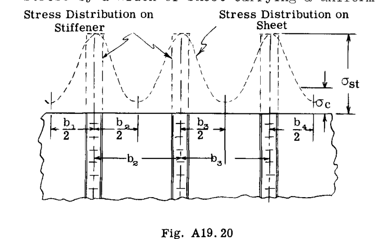

Fig. A19.20

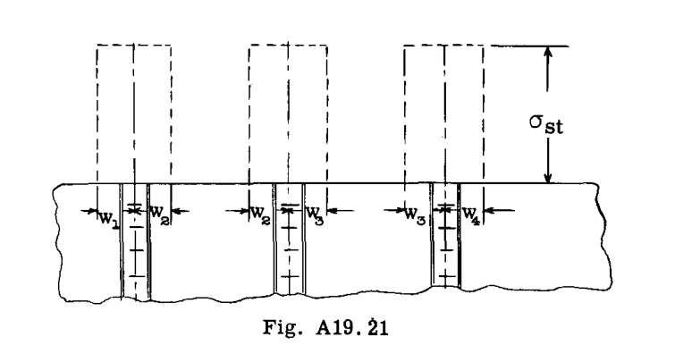

Fig. A19.21

この応力はストリンガー応力に等しい。Fig. A19.21 において、 $2w$ は各ストリンガーに付随する有効外板幅である。ストリンガー応力に等しい均一応力を負担する有効幅上の全応力は、実際の変動する応力分布を負担する外板パネル上の全荷重に等しい。有効幅の式は、通常以下の形式で記述される。

$$2w = kt \left( \frac{E}{\sigma_{st}} \right)^{\frac{1}{2}}$$

$K = 1.9$ という値が広く用いられており、これより以下が得られる。

$$2w = 1.90 t \left( \frac{E}{\sigma_{st}} \right)^{\frac{1}{2}} \quad \text{--- (1)}$$

$$\sigma_{st} = \text{ストリンガーの応力}$$

したがって、ストリンガーの応力が分かれば、外板の座屈の影響を考慮した有効断面を得るために、ストリンガーとともに考慮すべき外板幅を求めることができる。

### 座屈したストリンガーの有効係数

Fig. A19.17 の梁断面を考える。ストリンガー (c) を取り出し、これに有効幅 $2w$ に等しい外板を取り付け、これを圧縮状態で試験し、外板と平行な面内で支持拘束を施すと、Fig. A19.22 の曲線 (c) に示すような試験応力対歪み縮み曲線が得られる。試験片の長さは、翼のリブ間隔に等しくなる。Fig. A19.17 のコーナー部材 (a) または (b) は、2方向に安定化されているため、局所的なクリップリング（局部圧壊）によって破壊する。したがって、この部材の短い試験片を圧縮破壊試験にかけると、Fig. A19.22 の曲線 (A) が得られる。曲線 (C) は、ストリンガーがかなりの歪み領域にわたってほぼ最大荷重を維持することを示している。曲線 (A) は、同じ単位歪みに対して、部材 (a) がかなり高い応力を負担できることを示している。単位歪みを 0.006 とすると、部材 (a) で最大応力 47000 が得られる点（曲線 A の点 (3) を参照）となり、このとき部材 (C) の同じ歪みにおける応力は 38000 となる（曲線 C の点 (2) を参照）。

- 外板の座屈については、第C5章で詳細に扱う。

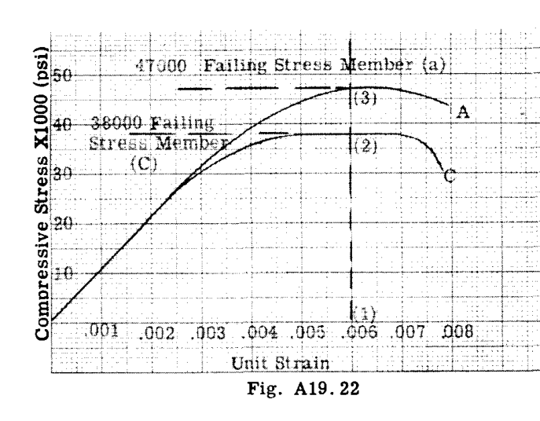

Fig. A19.22

梁公式を用いた応力解析手順では、0 から 47000 psi まで線形に応力が変化すると仮定する。ストリンガー (c) は同じ歪みにおいて 38000 psi しか負担できないため、換言すれば、ストリンガー (c) は部材 (a) および (b) よりも効果が低い。ストリンガー (c) の有効係数は、その終局強度を部材 (a) の終局強度で除した値に等しく、 $38000/47000 = 0.808$ となる。

## A19.12 例題

Fig. A19.23 に示す翼断面に、x軸まわりに 500,000 in.lb. の設計曲げモーメントが作用し、上部が圧縮される方向を向いている。この設計曲げモーメントに対する安全余裕を決定することが問題である。材料は 2024 アルミニウム合金である。

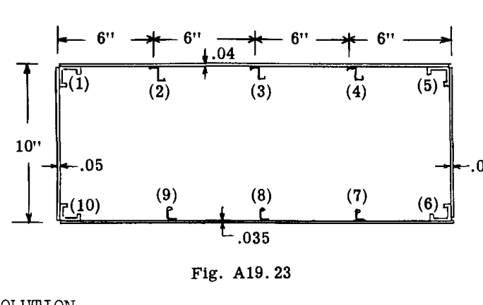

Fig. A19.23

### 解答

任意の点における曲げ応力の梁公式は $\sigma_b = M_x z / I_x$ である。この方程式を解くためには、梁断面の有効慣性モーメントが必要である。底面は、与えられた設計曲げモーメント下で引張を受けるため、すべて有効であるが、上面は、外板、ストリンガー、およびコーナーフランジ部材の終局破壊応力が異なるため、有効性が変化する。

式 (1) より、各リベット線において考慮すべき外板の有効幅は、それが取り付けられているストリンガーの応力に依存する。ストリンガーの破壊応力が使用されるが、これは有効幅を求める前に、ストリンガーおよびコーナーフランジの破壊応力を知っておく必要があることを意味する。この例では、Z型ストリンガーは終局柱破壊応力が 38000 psi となるようなサイズが選択されており、コーナーフランジ部材は破壊応力が 47000 psi となるようなサイズと形状に作られている。これらの破壊応力は、第C7章に示されている理論および方法によって計算することができる。これらのサイズは、Fig. A19.22 の試験曲線で表される強度を与えるように意図的に選択されている。

式 (1) による各リベット線における有効幅は、以下のようになる。

Z型ストリンガーについて：
$$2w = 1.90 \times 0.04 \left( \frac{10.5 \times 10^6}{38000} \right)^{\frac{1}{2}} = 1.25 \text{ インチ}$$

したがって、有効外板の面積 $= 1.25 \times 0.04 = 0.05 \text{ in.}^2$ である。Z型ストリンガーの面積は $0.135 \text{ sq. in.}$ であり、これを有効外板面積に加えると $0.185 \text{ sq. in.}$ となり、この値は Table A19.1 の Column (2) の Z型ストリンガー 2, 3, 4（Fig. A19.23）の行に入力される。同様の手順をコーナー部材 1 および 5 について行い、その結果得られた有効面積を Table A19.1 に示す。引張側となる底面については、すべての材料が有効である。隣接するストリンガーまでの距離の半分に等しい外板幅が、各ストリンガーとともに作用するものと仮定する。アングル断面の面積を 0.11 とし、 $6 \times 0.035 = 0.21$ に等しい外板面積を加えると、合計 $0.32 \text{ sq. in.}$ となり、この値は Table A19.1 の Column (2) のストリンガー 7, 8, 9 の行に示されている。下部コーナー部材に底面外板およびウェブ外板を加えた面積は、表に記録されている通りとなる。

次のステップは、圧縮におけるストリンガー有効性の補正である。Z型ストリンガーの破壊応力は 38000 psi、コーナー部材は 47000 psi と与えられていた。したがって、Z型ストリンガーの有効係数は $38000/47000 = 0.808$ となる。この係数は Table A19.1 の Column (3) に記録されている。コーナー部材 1 および 5、ならびにすべての引張部材について、この係数は当然 1.0 である。Table A19.1 の残りの部分は、x中立軸まわりの有効慣性モーメント $\Sigma A z^2$ の計算を示している。

Z型ストリンガーの図心における圧縮応力の強さは、以下のようになる。

$$\sigma_b = \frac{M_x z}{I_x} = \frac{500,000 \times 5.57}{59.80} = 46600 \text{ psi}$$

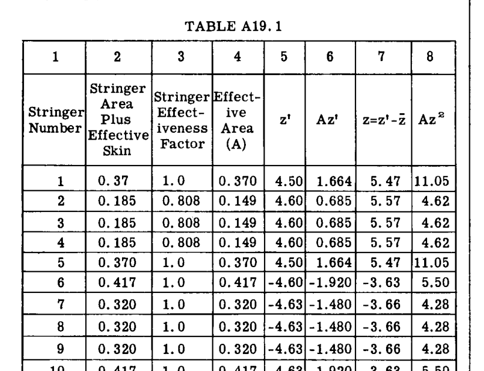

Table A19.1

ここで、ストリンガーの有効係数の考慮を省略し、Table A19.1 の Column (3) を省略したと仮定しよう。Table A19.1 の計算を進めると、 $\bar{z}$ の値は -0.76" となり、 $I_x$ は 63.08 となる。このとき、Z型ストリンガーにおける応力強さは、以下のようになる。
$$500000 \times 5.36 / 63.08 = 42500 \text{ psi}$$
ストリンガーの破壊応力は 38000 であるため、安全余裕は $(38000/42500) - 1 = -10.5 \text{ パーセント（負）}$ となる。先ほどの結果はプラス 1 パーセントであったため、結果に 11.5 パーセントの差が生じる。

この簡単な例題の目的は、実際の航空機の補強外板構造の破壊が非線形な応力-歪み条件下で発生すること、および複合構造の破壊強度を精度よく推定するためには弾性理論を修正する必要があることを、学生に強調することであった。

## A19.13 テーパー型マルチストリンガー片持ち翼の曲げおよび剪断応力解析（不対称梁法）

一般に、片持ち翼は高さ方向および平面的にテーパー（先細り）している。Fig. A19.24 は、小型飛行機の外側翼パネルの代表的な構造配置を示している。構造は、前部梁および後部梁（スパー）と、2本の梁の間のスパン方向のストリンガーで構成されている。断面材料のテーパーは、スパン方向のストリンガーやコーナーフランジの一部を途中で切り落として部材寸法を小さくし、外板およびウェブの厚さを薄くすることによって得られる。

この翼の応力解析を行うと、重大な設計荷重条件に対する多くのスパン位置における、曲げ応力および剪断応力が得られる。この例題の解法では、曲げ縦応力は2つの位置、すなわちステーション 20 と 47.5 の断面で決定され、剪断応力はステーション 20 で決定される。この例題では、前縁セルは無効と見なし、後部梁より後方の構造も同様とする。したがって、構造は複数のストリンガーを持つ1セル梁である。前縁セルを含めて2セル梁を構成する第2の解法も示される。

### 曲げ縦応力の解析

縦応力（引張または圧縮）は、断面に垂直な外力およびx軸、z軸まわりの曲げモーメントによって発生する。応力方程式は以下のものである。

$$\sigma_n = \frac{P}{A} \quad \text{--- (2)}$$

ここで、 * $\sigma_n$ = 縦応力 * $P$ = 有効翼断面の図心に作用する外荷重 * $A$ = 断面の有効面積

面積 $a$ を持つ任意のフランジ部材について、部材上の荷重 $P_n$ は以下のようになる。

$$Pn = \sigma_n a \quad \text{--- (3)}$$

曲げモーメントによる応力は、第A13章 A13.5節より、以下のようになる。

$$\sigma_b = -(K_3 M_z - K_1 M_x)x - (K_2 M_x - K_1 M_z)z \quad \text{--- (4)}$$

ここで、 $\sigma_b$ は曲げ応力であり、プラスが引張である。

$$K_1 = \frac{I_{xz}}{I_x I_z - I_{xz}^2}$$
$$K_2 = \frac{I_z}{I_x I_z - I_{xz}^2}$$
$$K_3 = \frac{I_x}{I_x I_z - I_{xz}^2}$$

フランジ部材における軸方向荷重の垂直成分は $\sigma_b a$ に等しい（ここで $a$ はフランジ部材の面積）。梁断面に対する法線とストリンガーの図心軸とのなす角は一般に非常に小さいため、小さな角のコサインと1との差は無視でき、したがって垂直成分をストリンガー内の軸荷重と見なすことができる。

式 (2)、(3)、(4) を解く前に、有効断面積、ならびに図心x軸およびz軸まわりの慣性モーメントおよび相乗モーメントを知る必要がある。

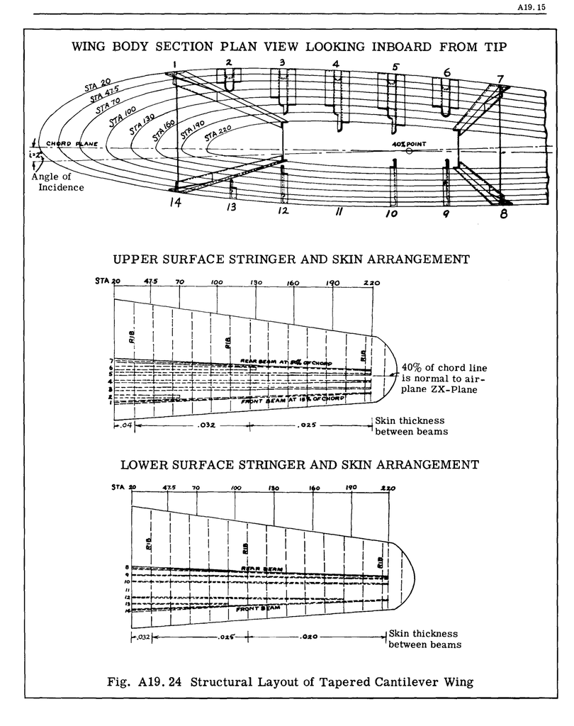

Fig. A19.24

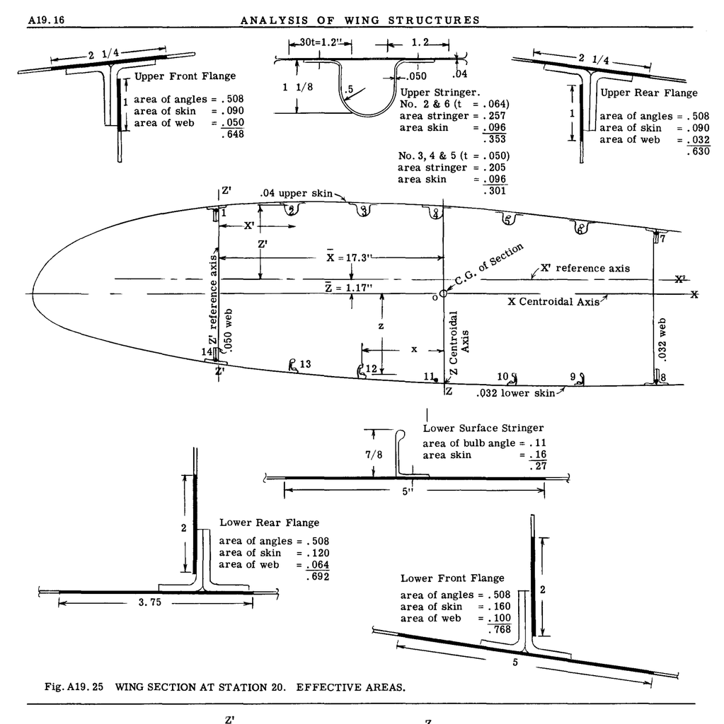

Fig. A19.25

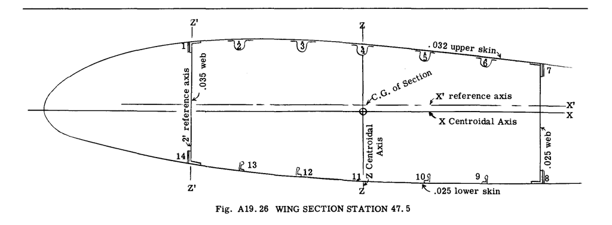

Fig. A19.26

Fig. A19.25 は、ステーション 20 における断面を、1 から 14 まで番号が振られた 14 個の縦方向ユニットに分割したものである。使用する外力条件によって上面が圧縮されるため、外板は座屈し、したがって有効幅の手順を用いて、各ストリンガーとともに作用する外板部分を求める。Fig. A19.25 は、各フランジ部材とともに用いられ、1 から 7 までの総面積を与える有効外板を示している。底面の外板は引張状態にあるためすべて有効であり、Fig. A19.25 は、各底部フランジ部材とともに用いられる外板面積を示している。

次に決定すべき要因は、前述の例題で議論および説明されたストリンガーの有効性である。Fig. A19.25 の構造については、ストリンガーの圧縮破壊応力がコーナー部材の破壊応力と同じであると仮定するため、終局強度の異なるフランジ部材が存在する状況を考慮するための補正係数は不要である。

Table A19.2 の Column 1 から 11、および表の下の計算は、ステーション 20 における断面特性、すなわち $A$ 、 $I_x$ 、 $I_z$ 、および $I_{xz}$ を決定するための計算を示している。Table A19.3 は、ステーション 47.5 における翼断面について同様のデータを示している。Column (2) の面積は、ステーション 20 と 47.5 の間でサイズが変化しているため、小さくなっている。

#### $M_x$ および $M_z$ 曲げモーメントによる縦応力の計算

設計曲げモーメントは以下のように仮定される。

ステーション 20:
$$M_x = 1,300,000 \text{ in.lb.}$$
$$M_z = -285,000 \text{ in.lb.}$$

ステーション 47.5:
$$M_x = 1,000,000 \text{ in.lb.}$$
$$M_z = -215,000 \text{ in.lb.}$$

y軸まわりのモーメントは、曲げ応力解析には不要であるが、後で作成される剪断解析に必要である。

式 (4) を解くためには、定数 $K_1$ 、 $K_2$ 、 $K_3$ を知る必要がある。

Table A19.2 より、ステーション 20 については、 $I_x = 230.3$ 、 $I_z = 1030$ 、および $I_{xz} = -50$ となり、以下が得られる。

$$K_1 = \frac{I_{xz}}{I_x I_z - I_{xz}^2} = \frac{-50}{230.3 \times 1030 - (-50)^2} = \frac{-50}{235500} = -0.0002125$$
$$K_2 = \frac{I_z}{235500} = \frac{1030}{235500} = 0.004378$$
$$K_3 = \frac{I_x}{235500} = \frac{230.3}{235500} = 0.00098$$

式 (4) に代入すると、

$$\sigma_b = -[0.00098 \times (-285000) - (-0.0002125 \times 1,300,000)]x - [0.004378 \times 1,300,000 - (-0.0002125 \times (-285000))]z$$

これより、
$$\sigma_b = 3.3x - 5639z \quad \text{--- (5)}$$

Table A19.2 の Column 12 は、Column 10 と 11 の $x$ および $z$ の値に対するこの方程式の結果を示している。これらの曲げ応力にストリンガー面積を乗じることで、ストリンガー荷重が Column 13 に与えられる。曲げを受ける断面上の全引張は全圧縮に等しくなければならないため、この列の荷重の総和はゼロになるはずである。

ステーション 47.5 における応力：

Table A19.3 より、
$$I_x = 157.4, \quad I_z = 700, \quad I_{xz} = -35.4$$

$$K_1 = \frac{-35.4}{157.4 \times 700 - (-35.4)^2} = \frac{-35.4}{108950} = -0.000324$$
$$K_2 = \frac{700}{108950} = 0.00643$$
$$K_3 = \frac{157.4}{108750} = 0.001447$$

$$\sigma_b = -[0.001447 \times (-215000) - (-0.000324 \times 1,000,000)]x - [0.00643 \times 1,000,000 - (-0.000324 \times (-215000))]z$$

これより、
$$\sigma_b = -14.5x - 6360z$$

Table A19.3 の Column 12 はこの方程式の結果を与え、Column 13 はステーション 47.5 における総ストリンガー荷重を与える。

各表の Column 12 の応力は、安全余裕を得るためにフランジ部材の破壊応力と比較される。

### ウェブおよび外板における剪断応力の解析

剪断流分布は、ステーション 20 と 47.5 の間のストリンガーにおける軸方向荷重の変化（一般に $\Delta P$ 法と呼ばれる方法）を用いて計算される。この方法の説明については、第A15章 A15.16節を参照されたい。

セル壁の点 n における y 方向の剪断流は、以下に等しい。

$$q_n = q_o - \sum_o^n \frac{\Delta P}{d} \quad \text{--- (6)}$$

ここで、 $q_o$ はある点 o における剪断流の既知の値であり、第2項は点 o と n の間の剪断流の変化である。

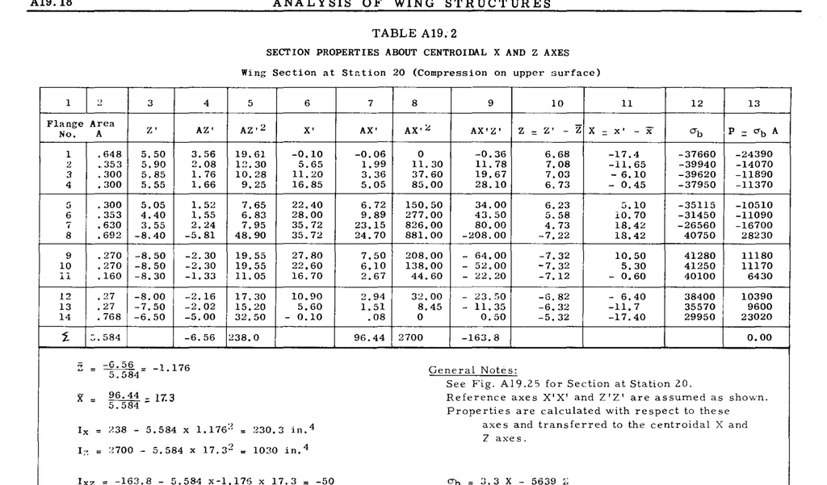

Table A19.2

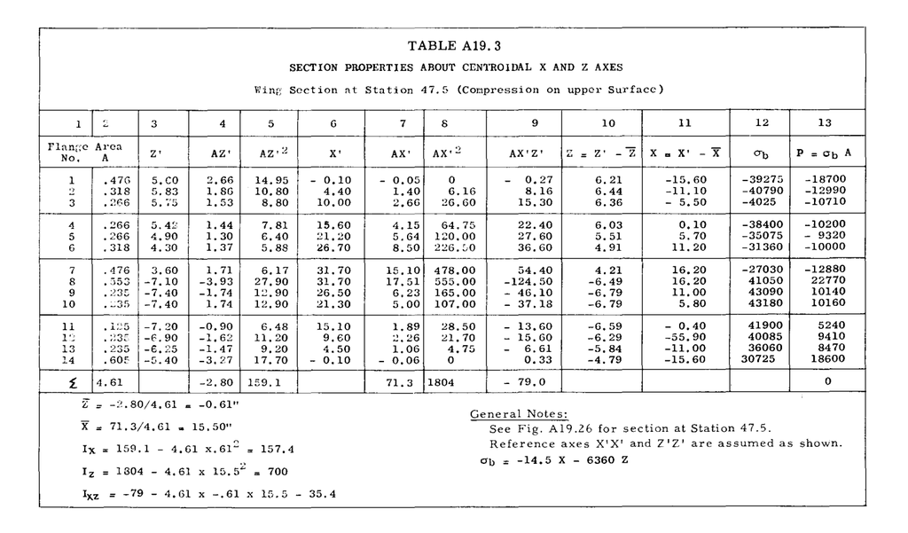

Table A19.3